# Examen R : Les volcans

Emma Montanuy

16/11/2021

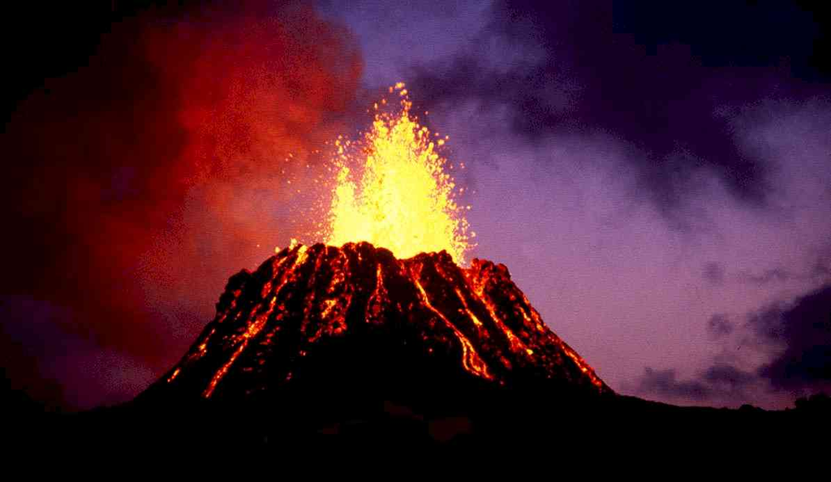

## Base de données

Les données sur lesquelles nous allons travailler ont été trouvées sur la page *TidyTuesday*. Ces dernières ont été recueillies par l’institut de recherche américain *Smithsonian Instituion*. Etudier des données sur les éruptions volcaniques est utile car des études montrent que les éruptions volcaniques peuvent influencer le climat. Nous allons utiliser deux bases de données, *volcano* et *eruptions*. La base de données *volcano* comporte 958 volcans. Pour chaque volcan, nous avons son nom, son type, l’année de sa dernière éruption, sa région, sa sous région, sa latitude/longitude, sa hauteur ainsi que la population qui habitent à 5/10/30/100kms. Chaque volcan est identifié par un numéro. La base de données *eruptions* comporte 11 178 observations. Pour chaque éruption, nous pouvons trouver le nom du volcan, les date de début et de fin d’éruption( format année/mois/ jour). Chaque éruption est identifiée par un numéro.

## Volcans

#### **1/Quelle est la hauteur moyenne des volcans ?**

```r
round(mean(volcano$elevation, na.rm=T), digits=0)%>%
  kbl(col.names ="Hauteur moyenne des volcans en mètres")
```

| Hauteur moyenne des volcans en mètres |
| --- |
| 1867 |

#### **2/Combien y-a-t-il de pays présents dans notre base de données?**

```r
nbre_volcan_pays <- volcano%>%
  count(country)

nbre_volcan_pays%>%
  group_by(country)%>%
  nrow()%>%
  kbl(col.names = " Nombre de pays présents dans notre base de données")
```

| Nombre de pays présents dans notre base de données |
| --- |
| 89 |

#### **3/Parmi ces 89 pays, quels sont ceux qui comptent le plus de volcans? Affichage du top 10.**

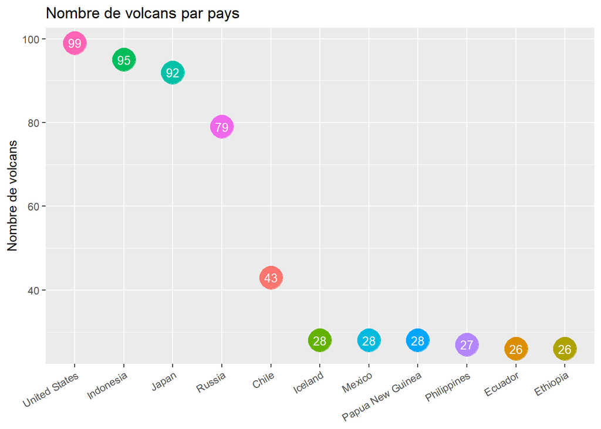

```r
nombre_pays_top10 <- nbre_volcan_pays %>%
  top_n(10)%>%
  arrange(-n)


nombre_pays_top10 %>%
  ggplot(aes(x=reorder(country,-n),y=n, color=country))+
  geom_point( size=9) +
  labs(y = "Nombre de volcans",title = "Nombre de volcans par pays")+
  theme(axis.text.x = element_text(angle=30, hjust=1),legend.position ="none",axis.title.x = element_blank())+
  geom_text(aes(label=n), vjust=0.5, color="white", size=3.5)
```

11 pays sont présents car il y a égalité sur le nombre de volcans entre l’Equateur et l’Ethiopie.

#### **4/Qu’est-ce que la somme de ces volcans représente par rapport au nombre total de volcans présents dans la base de données?**

Calcul de la part de volcans se trouvant dans les 10 pays qui comptent le plus de volcans par rapport au nombre total de volcans.

```r
part_volcan_top10 <-sum(nombre_pays_top10$n)/sum(nbre_volcan_pays$n)

part_volcan_top10
```

Création d’un data frame.

```r
Tableau <-data.frame(Volcans =c("Dans le top 10 des pays","Dans les autres pays"),Part=c(round(part_volcan_top10,digits=3),round(1-part_volcan_top10,digits=3)))

Tableau %>%
  kbl()
```

| Volcans | Part |
| --- | --- |
| Dans le top 10 des pays | 0.596 |
| Dans les autres pays | 0.404 |

Création d’un plot.

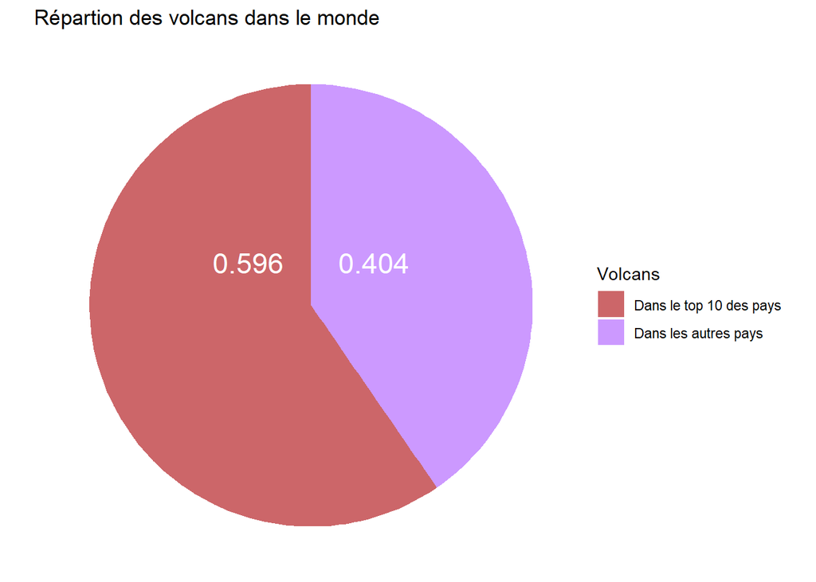

```r
Tableau%>%
 ggplot(aes(x = "", y = Part, fill=Volcans)) +
  geom_col()+
  coord_polar("y", start = 0)+
  theme_void()+
  geom_text(aes(label= Part), color="white", vjust=-6, size=6)+
  scale_fill_manual(values=c("#CC6669", "#CC99FF"))+
  labs(title = "Répartion des volcans dans le monde")
```

#### **5/Combien y-a-t-il de régions présentes dans notre base de données?**

```r
nbre_region <- volcano%>%
 count(region)%>%
 group_by(region)%>%
 nrow()
nbre_region %>% kbl(col.names = "Nombre de régions présentes dans notre base de données")
```

| Nombre de régions présentes dans notre base de données |
| --- |
| 19 |

#### **6/ Dans les 5 régions qui comptent le plus de volcans, quelles sont par région les hauteurs moyennes des volcans?**

Création d’un sous tableau afin d’obtenir pour chaque région la hauteur des volcans qu’elle comporte.

```r
ac <- volcano%>%
  group_by(region)%>%
  pivot_wider(names_from = region,values_from=elevation)
ac2 <- ac[,-c(1:24)]
```

Comptage du nombre de volcans par régions et conservation des 5 régions avec le plus de volcans.

```r
région_count <-volcano %>%
  group_by(region)%>%
  count()%>%
  arrange(-n)

R <- région_count[1:5,]

R %>% rename(Region=region)%>%
  rename("Nombre de volcans"=n)%>%
  kbl()
```

| Region | Nombre de volcans |
| --- | --- |
| South America | 117 |
| Japan, Taiwan, Marianas | 102 |
| Indonesia | 95 |
| México and Central America | 93 |
| Africa and Red Sea | 79 |

Calcul de la hauteur moyenne des volcans pour les 5 régions qui comptent le plus de volcans.Création d’un data frame à partir de ces données et création d’un plot. Les moyennes sont arrondies à l’unité.

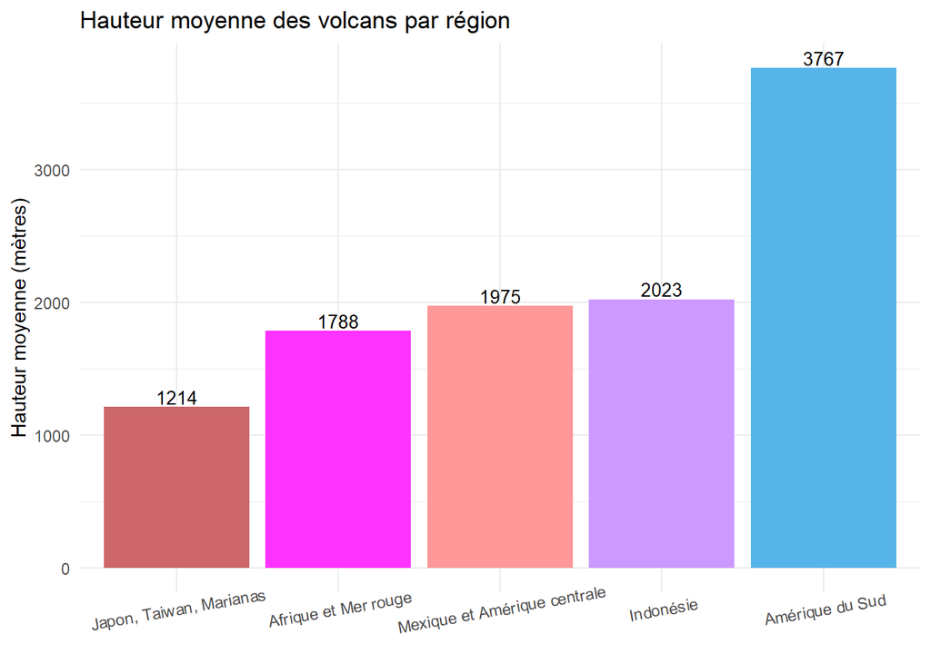

```r
a <-round(mean(ac2$`South America`,na.rm=T))
b<- round(mean(ac2$`Japan, Taiwan, Marianas`,na.rm=T))
c<- round(mean(ac2$Indonesia,na.rm=T))
d <- round(mean(ac2$`México and Central America`,na.rm=T))
e <- round(mean(ac2$`Africa and Red Sea`,na.rm=T))

hauteur_moyenne_région <- c(a,b,c,d,e)
région <- c("Amérique du Sud", "Japon, Taiwan, Marianas", "Indonésie", "Mexique et Amérique centrale", "Afrique et Mer rouge")

D <- data.frame(région, hauteur_moyenne_région)
D%>%
  ggplot(aes(reorder(région,hauteur_moyenne_région),hauteur_moyenne_région,fill=région))+ geom_col()+
  labs(x= "Régions", y="Hauteur moyenne (mètres)", title="Hauteur moyenne des volcans par région")+
  theme_minimal()+
  geom_text(aes(label=hauteur_moyenne_région), vjust=-0.2, color="black", size=3.5)+
  theme(axis.text.x = element_text(angle=10, hjust=0.5),axis.title.x = element_blank(),legend.position ="none")+
  scale_fill_manual(values=c("#FF33FF", "#56B4E9", "#CC99FF", "#CC6669","#FF9999"))
```

#### **7/Dans les 5 régions qui comptent le plus de volcans, quel est le nombre de personnes qui habitent proches d’un volcan?**

Création d’un sous tableau du nombre d’habitants vivant à 5 kms d’un volcan pour chaque région.

```r
ety <- volcano%>%
  group_by(region)%>%
  pivot_wider(names_from = region,values_from=population_within_5_km)
ety2 <- ety[,-c(1:24)]
```

D’après la question précédente, nous connaissons les 5 régions qui comptent le plus de volcans. Création d’un data frame qui représente toutes les personnes habitant à 5kms (d’un volcan) pour chaque région.

```r
aa <- sum(ety2$`South America`,na.rm=T)
bb <- sum(ety2$`Japan, Taiwan, Marianas`,na.rm=T)
cc <- sum(ety2$Indonesia,na.rm=T)
dd <- sum(ety2$`México and Central America`,na.rm=T)
ee <- sum(ety2$`Africa and Red Sea`,na.rm=T)


habitant5km_région <- c(aa,bb,cc,dd,ee)
region <- c("South America", "Japon, Taiwan, Marianas", "Indonesia", "México and Central America", "Africa and Red Sea")

E <- data.frame(region, habitant5km_région )
E%>% kbl()
```

| region | habitant5km_région |
| --- | --- |
| South America | 1125800 |
| Japon, Taiwan, Marianas | 5668774 |
| Indonesia | 3343565 |
| México and Central America | 14010669 |
| Africa and Red Sea | 3745564 |

#### **8/ Y-a-t-il un lien entre le nombre de volcans par région et le nombre d’habitants vivant proche d’un volcan?**

Création du plot(EE) sans l’afficher grâce au data frame *E* (région, habitants à 5kms).

```r
EE <- E%>%
  ggplot(aes(reorder(region,habitant5km_région),habitant5km_région, fill=region))+    geom_col()+
  labs(x="Région", y="Nombre de personnes habitant à 5kms d'un volcan", title="Nombre d'habitants à 5 kms d'un volcan par région ( Top 5)")+
  theme_classic()+
  coord_flip()+
  scale_fill_brewer(palette="Paired")+
  theme(axis.title.x = element_blank(),axis.title.y = element_blank(),legend.position ="none")
```

Création du plot ( EEE) sans l’afficher grâce au data frame *région_count* (région, nombre de volcans).

```r
EEE <- région_count[1:5,]%>%
  ggplot(aes(x=reorder(region,n),y=n, fill=region))+
  geom_col()+
  labs(x="Région", y="Nombre de volcans", title="Nombre de volcans par région ( Top 5)")+
  scale_y_continuous(breaks=c(0, 20, 40,60,80,100,120))+
  theme_classic()+
  geom_text(aes(label=n),color="white",hjust=1.5, size=3.5)+
  coord_flip()+
  scale_fill_brewer(palette="Paired")+
  theme(axis.title.x = element_blank(),axis.title.y = element_blank(),legend.position ="none")
```

Affichage des 2 plots (EE, EEE) simultanément.

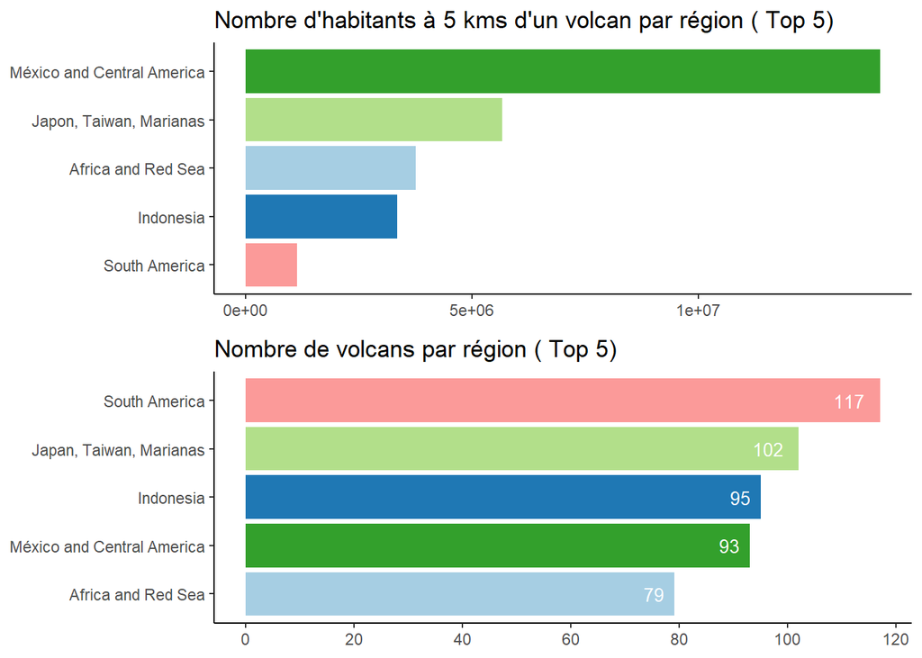

```r
grid.arrange(EE, EEE, ncol=1, nrow = 2)
```

## Eruptions

#### **9/ Quels sont les 15 derniers volcans à être entrés en eruption (noms des volcans et dates d’éruption)?**

```r
top_15 <- eruptions %>%
  select(volcano_name, start_day, start_month, start_year)%>%
  arrange(-start_year, -start_month, -start_day)%>%
  unite(col="date_dernière_eruption", start_day, start_month, start_year,sep=".", na.rm=T)%>%
  slice(1:15)
top_15 %>%
   kbl(col.names = c('Nom du volcan','Date de la dernière éruption'))
```

| Nom du volcan | Date de la dernière éruption |
| --- | --- |
| Soputan | 23.3.2020 |
| San Miguel | 22.2.2020 |
| Fournaise, Piton de la | 10.2.2020 |
| Rincon de la Vieja | 31.1.2020 |
| Fernandina | 12.1.2020 |
| Taal | 12.1.2020 |
| Kuchinoerabujima | 11.1.2020 |
| Whakaari/White Island | 9.12.2019 |
| Semisopochnoi | 7.12.2019 |
| Nishinoshima | 5.12.2019 |
| Cleveland | 7.11.2019 |
| Kikai | 2.11.2019 |
| Klyuchevskoy | 24.10.2019 |
| Lateiki | 13.10.2019 |
| Asamayama | 7.8.2019 |

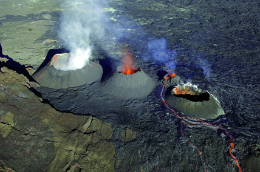

#### **10/Quelle est la durée moyenne d’une éruption ?**

Concaténation de 3 colonnes afin d’obtenir la date de début d’éruption. Transformation de ces dates au format *date*.

```r
début <- eruptions %>%
  select(start_year, start_month, start_day) %>%
  unite (col="date_début_dernière_eruption", start_year, start_month, start_day, sep="-", na.rm=T )
as.Date(début$date_début_dernière_eruption)
```

Concaténation de 3 colonnes afin d’obtenir la date de fin d’éruption. Transformation de ces dates au format *date*.

```r
fin<- eruptions %>%
  select(end_year, end_month, end_day) %>%
  unite (col="date_fin_dernière_eruption", end_year, end_month, end_day, sep="-", na.rm=T )
as.Date(fin$date_fin_dernière_eruption)
```

Différence entre la date de début d’éruption et la date de fin d’éruption.

```r
durée <- as.Date(fin$date_fin_dernière_eruption)-as.Date(début$date_début_dernière_eruption)
```

Calcul de la durée moyenne d’une éruption.

```r
round(mean(durée, na.rm=TRUE), digits=0)%>%
  kbl(col.names = "Durée moyenne d'une éruption")
```

| Durée moyenne d’une éruption |
| --- |
| 324 days |

#### **11/Affichons les volcans qui ont une hauteur connue. Comparons la hauteur moyenne des volcans de notre base de données avec la hauteur des derniers à être entrés en éruption.**

Parmi ces 15 volcans connaissons-nous les hauteurs de tous? Nous allons voir s’il y a des valeurs manquantes.

Jointure entre le *top_15* et la base de données *volcano*.

```r
top_10 <-top_15 %>%
  left_join(volcano, by="volcano_name")%>%
  select(volcano_name,elevation,date_dernière_eruption)
```

Calcul du nombre de hauteurs manquantes pour le top 15 des volcans.

```r
sum(is.na(top_10$elevation))%>%
  kbl()
```

| x |
| --- |
| 5 |

Suppression de ces 5 volcans. Nous obtenons les 10 derniers volcans, dont la hauteur est connue, à être entrés en éruption.

```r
top_10_NA <- top_10%>%
  drop_na()
```

Traçage du plot grâce aux différentes données extraites au dessus.

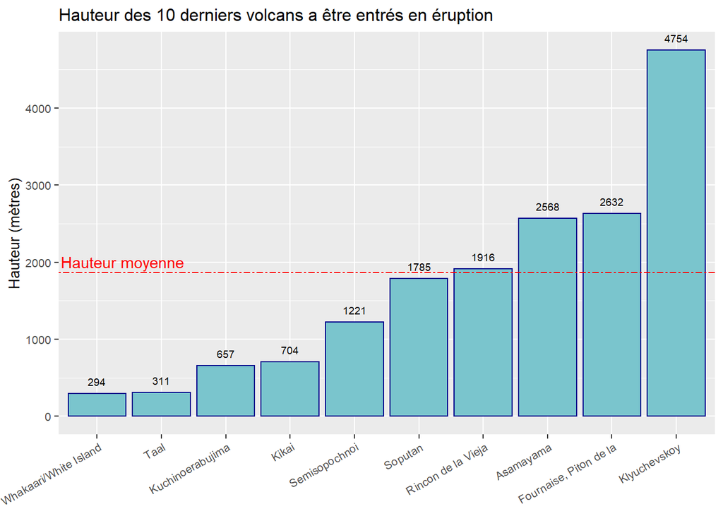

```r
top_10_NA %>%
  ggplot(aes(x=reorder(volcano_name,elevation),y=elevation, label=elevation))+
  labs(x = "Nom des volcans",
       y = "Hauteur (mètres)",
       title = "Hauteur des 10 derniers volcans a être entrés en éruption")+
  geom_col(color="darkblue", fill="cadetblue3")+
  theme(text = element_text(size=10),axis.text.x = element_text(angle=30,hjust=1),
    axis.title.x = element_blank())+
  geom_text(size=2.5, vjust=-1)+
  geom_hline(yintercept=mean(volcano$elevation, na.rm=T), color="red", linetype="twodash")+
  annotate("text", x = 1.4, y =2005, label ="Hauteur moyenne",color = 'red')
```

#### **12/ Quelle est la tendance des éruptions à travers le temps ?**

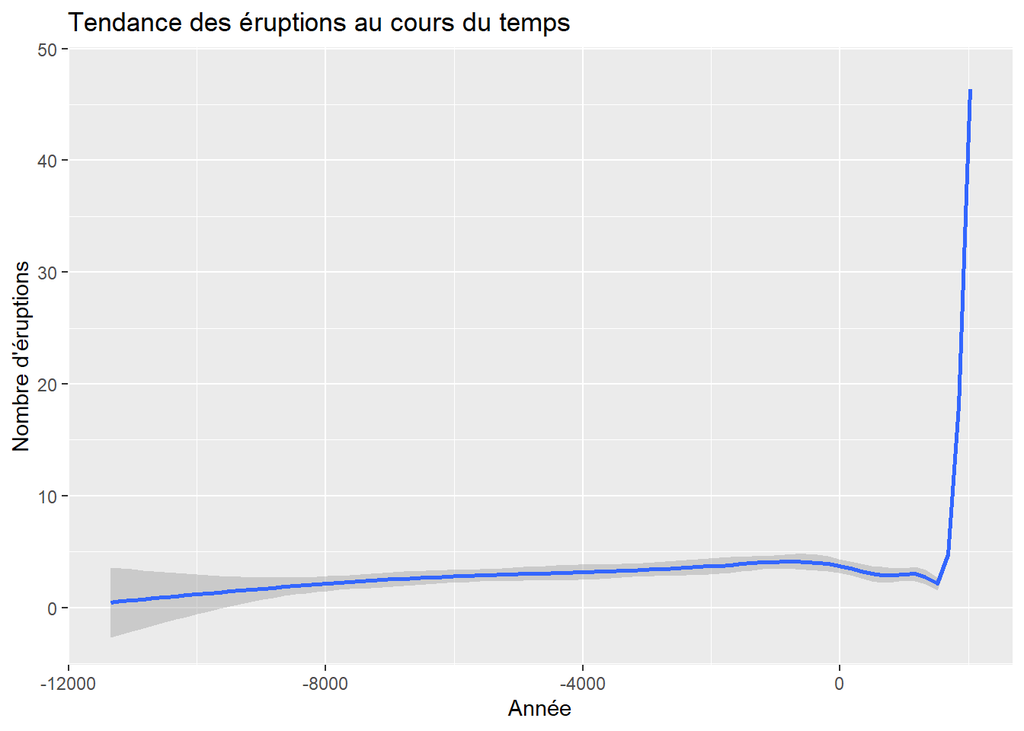

```r
eruptions%>%
  count(start_year)%>%
  ggplot(aes(x=start_year,y=n))+
  geom_smooth()+ labs(x="Année", y="Nombre d'éruptions", title = "Tendance des éruptions au cours du temps")
```

# Section par Paolo Crosetto

## Commentaire

Vous avez perdu un point parce que les questions que vous avez posées sont plutôt simples et ne vous mettent pas vraiment en difficulté et/ou vous mettent dans la position d’apprendre plus de choses. Sinon le travail est bien.

## Questions additionnelles

### 1. % in pie chart

La première question est toute simple et vous l’avez posée vous mêmes: vous ne saviez pas comment mettre les pourcentages dans le camembert. Voilà, c’est à faire!

**Réponse :**

```r
Tableau1 <-data.frame(Volcans =c("Dans les autres pays","Dans le top 10 des pays"),Part=c(round(100*(1-part_volcan_top10),digits=2),round(100*part_volcan_top10,digits=2)))

Tableau1 %>%
  kbl()
```

| Volcans | Part |
| --- | --- |
| Dans les autres pays | 40.4 |
| Dans le top 10 des pays | 59.6 |

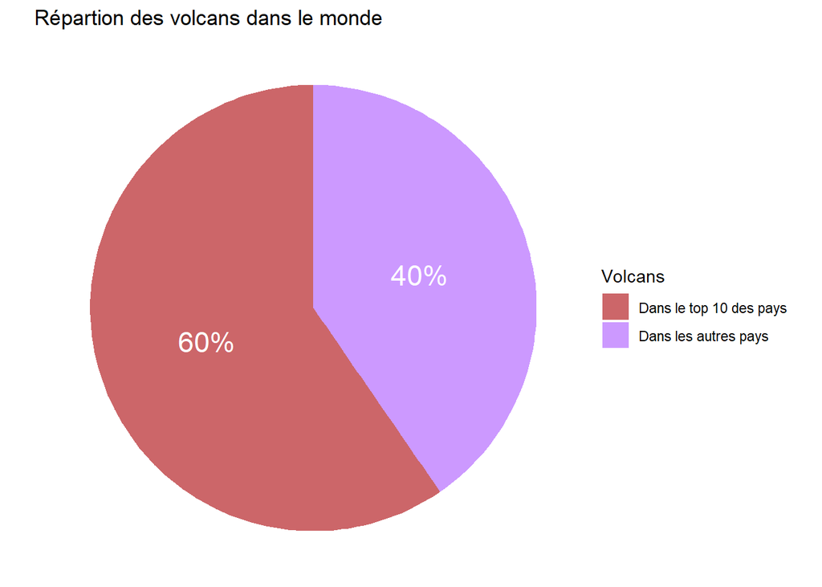

```r
Tableau1%>%
  ggplot(aes(x="", y=Part, fill=Volcans))+
 geom_bar(width = 1, stat = "identity") +
  coord_polar("y", start=0)+
  geom_text(aes(y = Part/2 + c(0, cumsum(Part)[-length(Part)]),
                label = percent(Part/100)), size=6, color = 'white')+
  theme_void()+
  scale_fill_manual(values=c("#CC6669", "#CC99FF"))+
  labs(title = "Répartion des volcans dans le monde")
```

### 2. Q7 plus compacte

Pourriez-vous refaire l’analyse de la question 7 d’une façon compacte et en utilisant les fonctions de tidyverse qu’on a vu en cours? J’ai pu la refaire en 3 (!) lignes de code, qui ont aussi beaucoup plus lisilbes. Essayez de faire au plus compact.

**Réponse :**

```r
volcano%>%
   group_by(region)%>%
  summarize(population=sum(population_within_5_km))%>%
    filter (region== "South America" | region == "Japan, Taiwan, Marianas" | region ==  "Indonesia" | region==  "México and Central America" | region==  "Africa and Red Sea")%>%
  kbl()
```

| region | population |
| --- | --- |
| Africa and Red Sea | 3745564 |
| Indonesia | 3343565 |
| Japan, Taiwan, Marianas | 5668774 |
| México and Central America | 14010669 |
| South America | 1125800 |

### 3. Durée des éruption

Le résultat qu’une éruption dure en moyenne 10 mois est vraiment étonnant. Il faut en savoir plus! Faites un plot de la distribution de la durée des éruptions par région. Visualisez les données en utilisant une ridgeline avec le package `ggridges`: https://cran.r-project.org/web/packages/ggridges/vignettes/introduction.html

**Réponse :** Dans un premier temps j’ai tenter d’améliorer mes données par rapport à ce que j’avais fait dans la question 10.  
Ainsi, dans un premier temps, je fais une jointure entre le tableau *volcano* et le tableau *eruptions* afin de pouvoir faire le lien entre les dates d’éruptions et les régions.

```r
H1 <- volcano %>%
left_join(eruptions, by="volcano_name")
```

Je selectionne la region ainsi que l’année, le mois, de jour de début et de fin d’éruption. Pour chaque jour, mois ou année qui est codé *0* ou qui est vide, j’assigne la valeur *NA*.

```r
H2 <- H1%>% select(region, start_year, start_month, start_day,end_year, end_month, end_day )
H2[H2 == ""|H2 == "0"]<-NA
```

Je supprime toutes les lignes qui comportent des *NA*. Ce qui me permet d’obtenir des dates complètes.

```r
H3 <- H2 %>% drop_na()
```

Je groupe les dates par région. J’unis les colonnes année de fin, mois de fin et jour de fin d’eruption en une seule; je fais de même avec l’année, mois et jour de début d’éruption. Je crée une nouvelle variable *durée1* qui est la différence entre la date de fin d’éruption et la date de début d’éruption -> j’obtiens la durée d’une éruption.

```r
H4 <- H3 %>% group_by(region)%>%
        unite (col="date_fin_dernière_eruption1", end_year, end_month, end_day,
        sep="-")%>%
       unite (col="date_début_dernière_eruption1", start_year, start_month,
       start_day, sep="-")%>%
       mutate(durée1=as.Date(date_fin_dernière_eruption1)-as.Date(date_début_dernière_eruption1))
H4
```

Je trace la distribution de la durée d’une éruption en fonction des régions.

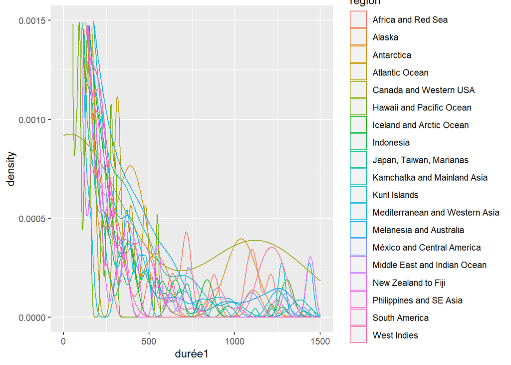

```r
ggplot(H4, aes(x=durée1, color=region)) +
  geom_density()+
  xlim(0,1500)+
  ylim(0,0.0015)
```

Nous ne voyons pas grand chose car les courbes se superposent. Nous allons donc utiliser le package *ggridges*

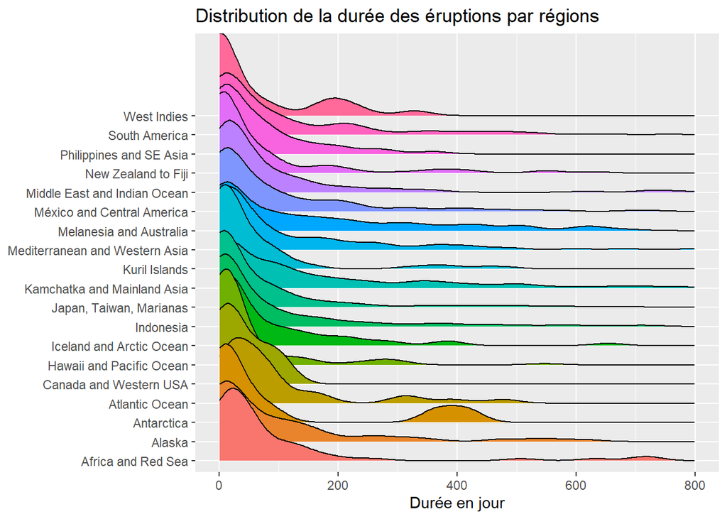

```r
library(ggridges)

ggplot(H4, aes(x=durée1,y=region, color=region)) +
  geom_density_ridges(aes(fill=region),scale=5, color="black")+
  xlim(0,800)+
  labs(x="Durée en jour", title = "Distribution de la durée des éruptions par régions")+
   theme(axis.title.y = element_blank(),legend.position ="none")
```

Grâce à ces distributions de densité, nous constatons que, peu importe la région, la majeure partie des éruptions a une durée comprise entre 1 et 150jours. Nous notons que certaines régions ont des particularités:

- Certains volcans de West Indies ( les Antilles) ont des éruptions plus longues,comprises entre 150 et 250 jours.
- Au Mexique et en Amérique Centrale, un nombre non négigeable de volcans a également des durées d’eruptions plus longues ( allant jusqu’à 600jours).
- Enfin, nous constatons que de nombreux volcans en Antartique ont une durée d’eruption comprise entre 350 et 450jours.

La très majeure partie des volcans ont des éruptions courtes(entre 0 et 3/4mois). Cependant nous constatons qu’un faible nombre de volcans ont des éruptions très, très longues ce qui fait tire la moyenne vers un chiffre très élevé! C’est pourquoi la durée moyenne d’éruption est à prendre avec des précautions.